# Acanthophora spicifera Hsat model

Angela Richards Donà

2024-05-14

This script runs a mixed effects model analysis of Hsat in minutes to see if treatment or temperature fixed effects had influence on this dependent variable.  
Supersat is the time above Ek for each individual in minutes, these are binned into three time periods from day 1 to day 9 Supersat avg is the mean of the three time periods

# Load the various libraries

```r
library(lme4)
library(lmerTest)
library(effects)
library(car)
library(MuMIn)
library (dplyr)
library(emmeans)
library(DHARMa)
library(performance)
library(patchwork)
library(rstatix)
#for plots and tables
library(ggplot2)
library(ggpubr)
library(forcats)
library(RColorBrewer)
library(tidyverse)
library(sjPlot)
library(sjmisc)
#library(mmtable2)
library(gt)
library(purrr)
library(stringr)
library(tidyr)
library(magrittr)
```

Read in the data

```r
ek_irrad_data <- read.csv("../transformed/acan_hsat_dspi.csv")
```

Assign variables as factors, characters, numeric, as needed

```r
ek_irrad_data$run <- as.factor(ek_irrad_data$run)
ek_irrad_data$temperature <- as.factor(as.character(ek_irrad_data$temperature))
ek_irrad_data$treatment <- as.factor(as.character(ek_irrad_data$treatment))
```

For plots-match up number of treatment with detailed

```r
ek_irrad_data$treatment_graph[ek_irrad_data$treatment == 0] <- "1) 35ppt/0.5umol"
ek_irrad_data$treatment_graph[ek_irrad_data$treatment == 1] <- "2) 28ppt/14umol"
```

For plots - same but for temp

```r
ek_irrad_data$temperature_graph[ek_irrad_data$temperature == 24] <- "1) 24 °C"
ek_irrad_data$temperature_graph[ek_irrad_data$temperature == 28] <- "2) 28 °C"
```

Make a histogram of the data

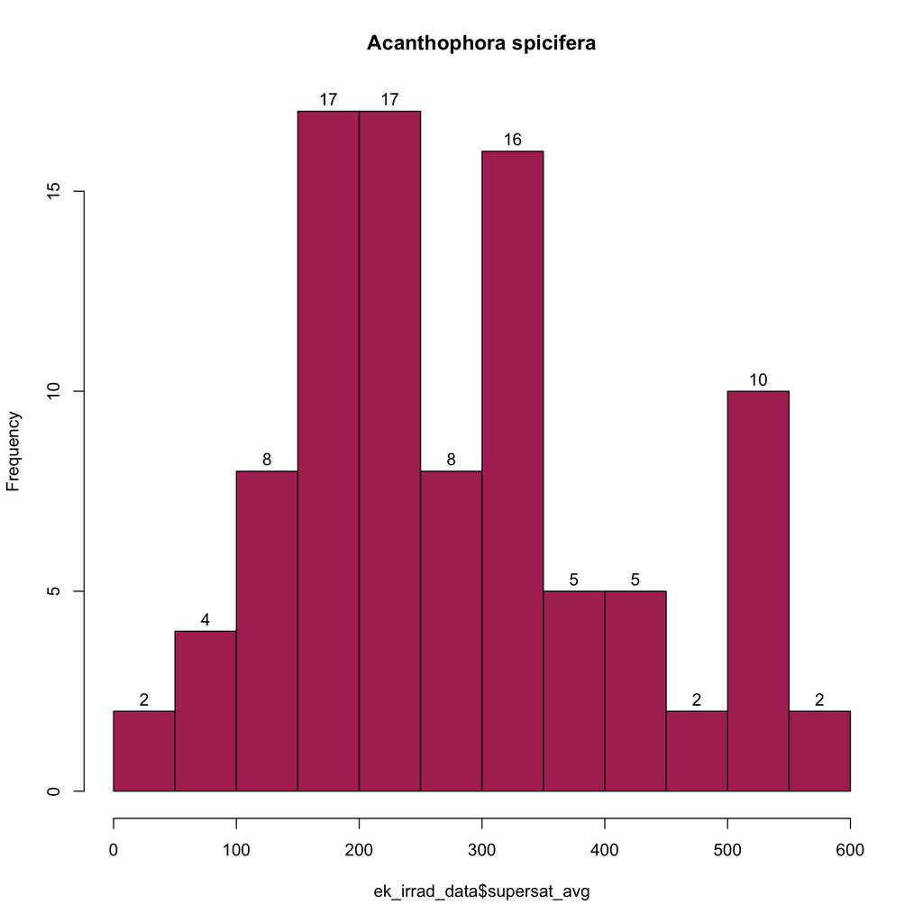

```r
hist(ek_irrad_data$supersat_avg, main = paste("Acanthophora spicifera"), col = "maroon", labels = TRUE)
```

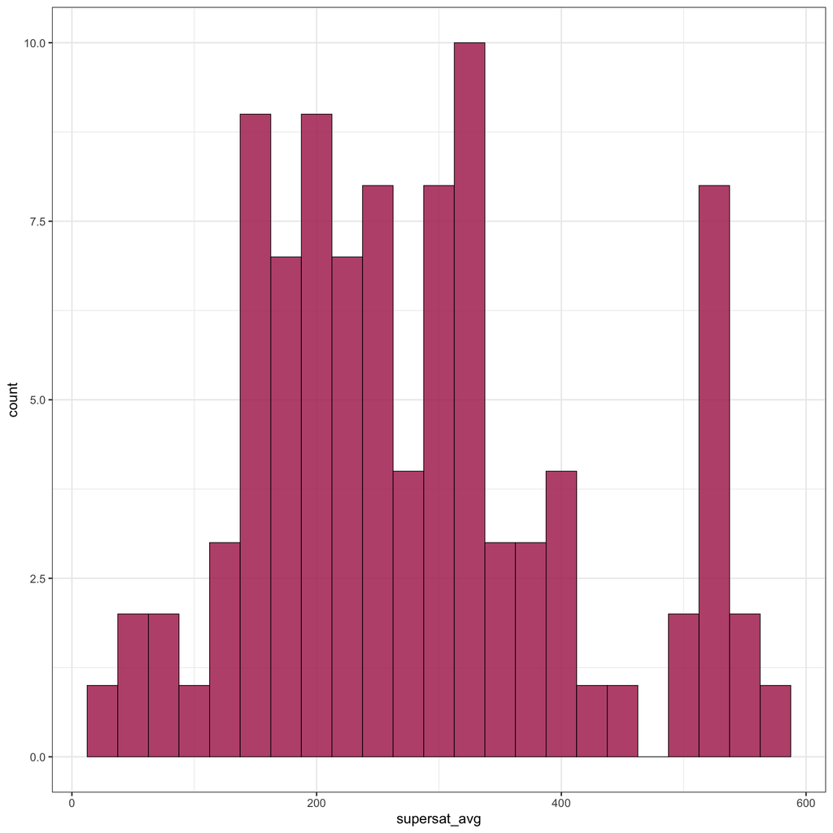

```r
ek_irrad_data %>% ggplot(aes(supersat_avg)) +
        geom_histogram(binwidth=25, fill = "maroon", color = "black", linewidth = 0.25, alpha = 0.85) +
        theme_bw()
```

Run model without interaction between the treatments and temperature - supersat_avg is in minutes

```r
hsat_model <- lmer(formula = supersat_avg ~ treatment + temperature + (1 | run) + (1 | plantID) + (1 | rlc_order), data = ek_irrad_data)
```

Check residual plots

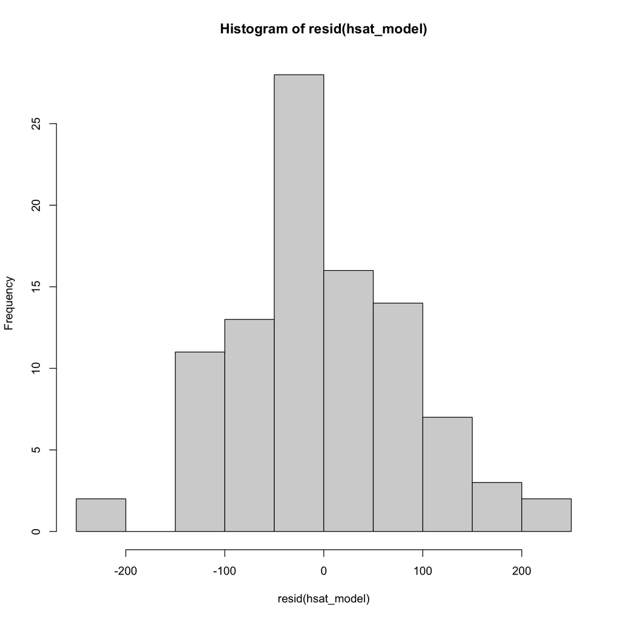

```r
hist(resid(hsat_model))
```

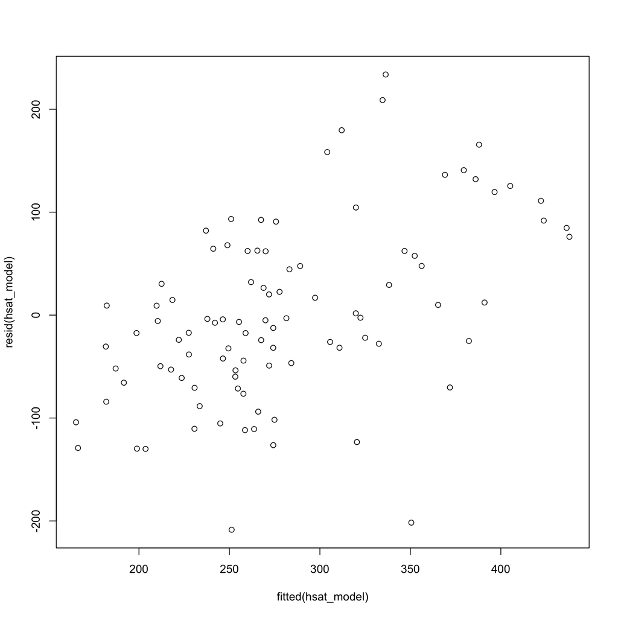

```r
plot(resid(hsat_model) ~ fitted(hsat_model))
```

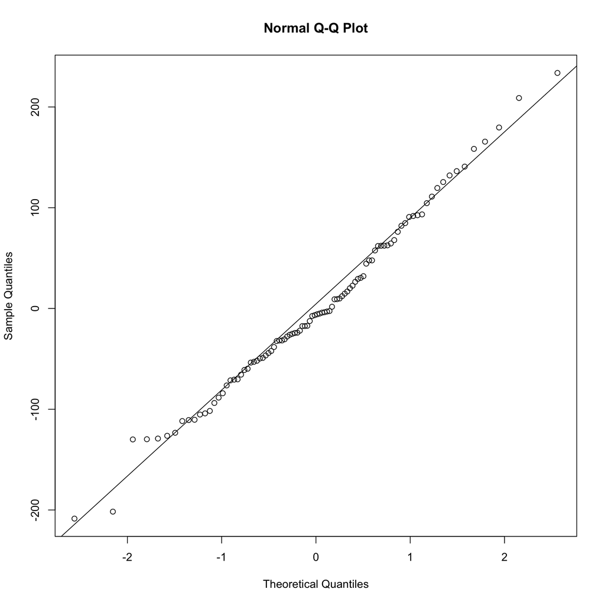

```r
qqnorm(resid(hsat_model))
qqline(resid(hsat_model))
```

Check the performance of the model

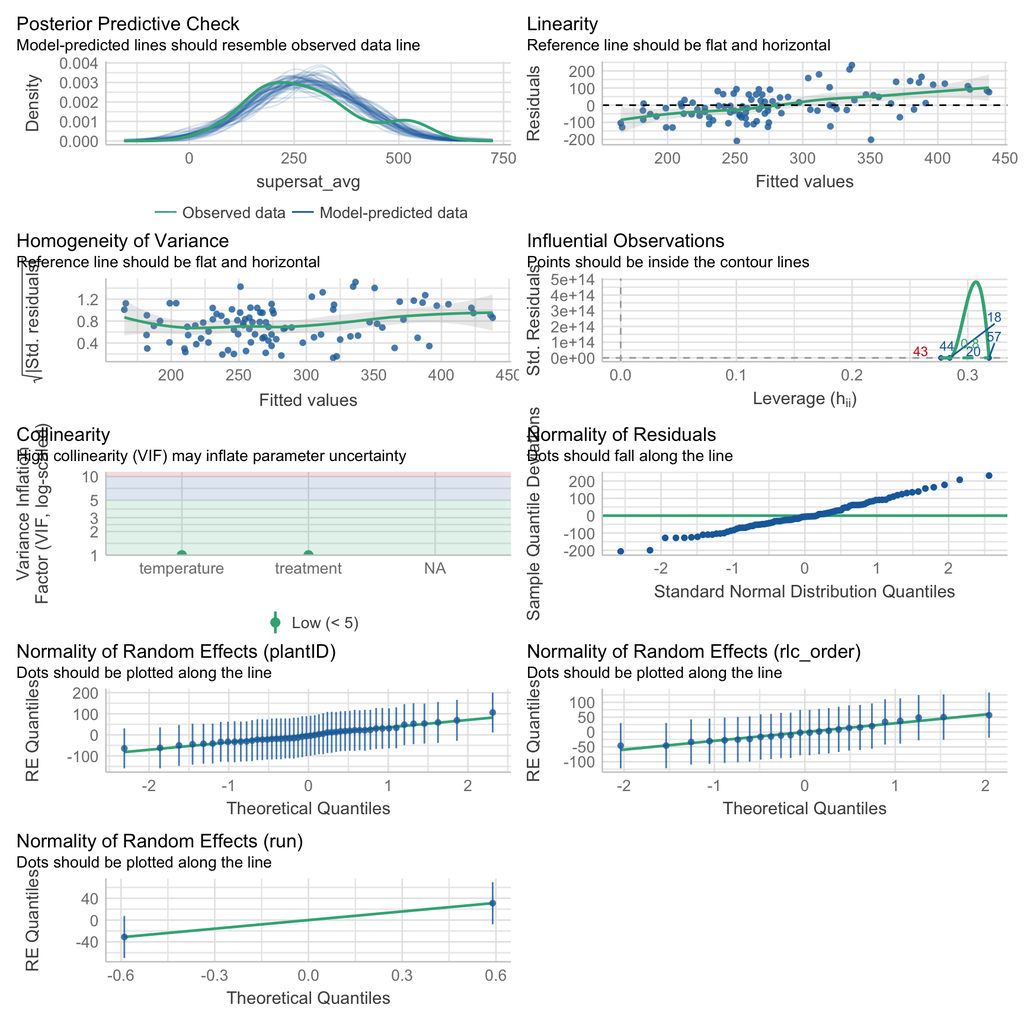

```r
performance::check_model(hsat_model)
```

```r
r.squaredGLMM(hsat_model)
```

```
##             R2m       R2c
## [1,] 0.01015503 0.4486889
```

```r
summary(hsat_model)
```

```
## Linear mixed model fit by REML. t-tests use Satterthwaite's method [
## lmerModLmerTest]
## Formula: supersat_avg ~ treatment + temperature + (1 | run) + (1 | plantID) +
##     (1 | rlc_order)
##    Data: ek_irrad_data
##
## REML criterion at convergence: 1173.2
##
## Scaled residuals:
##      Min       1Q   Median       3Q      Max
## -2.03527 -0.51856 -0.06039  0.60570  2.28131
##
## Random effects:
##  Groups    Name        Variance Std.Dev.
##  plantID   (Intercept)  3688     60.73
##  rlc_order (Intercept)  2423     49.22
##  run       (Intercept)  2241     47.34
##  Residual              10500    102.47
## Number of obs: 96, groups:  plantID, 48; rlc_order, 24; run, 2
##
## Fixed effects:
##               Estimate Std. Error      df t value Pr(>|t|)
## (Intercept)    285.137     42.673   1.925   6.682   0.0239 *
## treatment1      14.184     22.466  50.203   0.631   0.5307
## temperature28  -23.757     33.893  23.742  -0.701   0.4902
## ---
## Signif. codes:  0 '***' 0.001 '**' 0.01 '*' 0.05 '.' 0.1 ' ' 1
##
## Correlation of Fixed Effects:
##             (Intr) trtmn1
## treatment1  -0.263
## temperatr28 -0.397  0.000
```

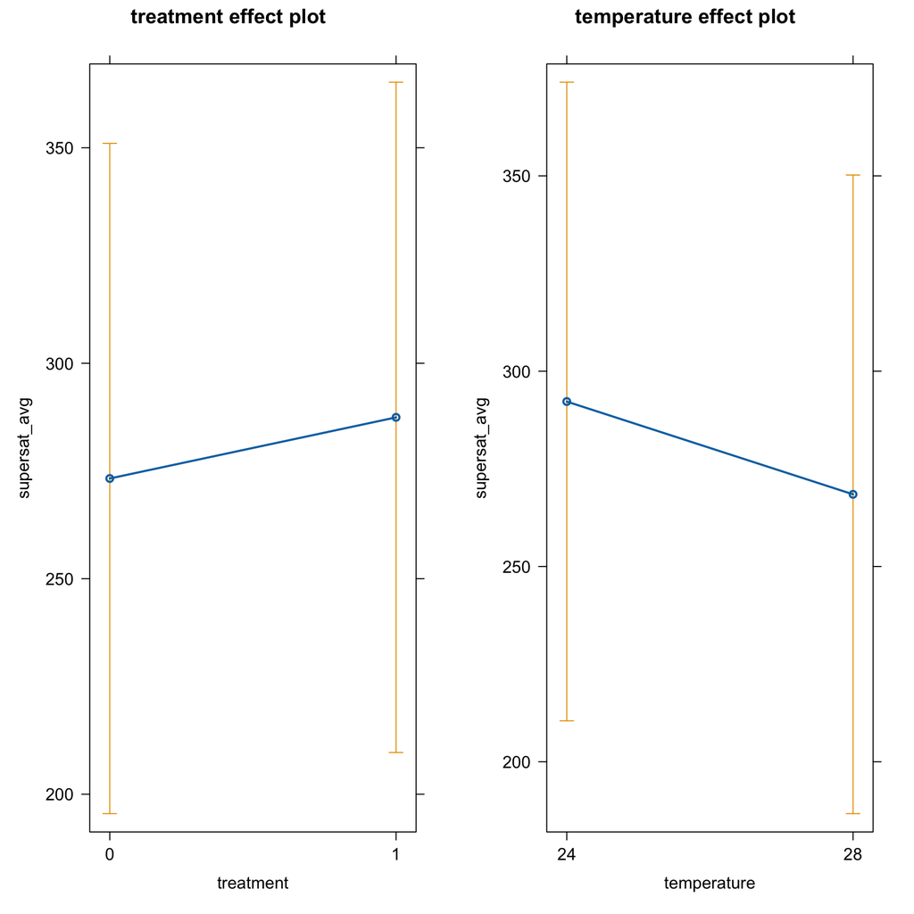

```r
plot(allEffects(hsat_model))
```

```r
tab_model(hsat_model, show.intercept = TRUE, show.se = TRUE, show.stat = TRUE, show.df = TRUE, show.zeroinf = TRUE)
```

|  | supersat_avg |  |  |  |  |  |
| --- | --- | --- | --- | --- | --- | --- |
| Predictors | Estimates | std. Error | CI | Statistic | p | df |
| (Intercept) | 285.14 | 42.67 | 200.35 – 369.93 | 6.68 | **<0.001** | 89.00 |
| treatment [1] | 14.18 | 22.47 | -30.46 – 58.82 | 0.63 | 0.529 | 89.00 |
| temperature [28] | -23.76 | 33.89 | -91.10 – 43.59 | -0.70 | 0.485 | 89.00 |
| Random Effects |  |  |  |  |  |  |
| σ<sup>2</sup> | 10500.22 |  |  |  |  |  |
| τ<sub>00</sub> <sub>plantID</sub> | 3688.41 |  |  |  |  |  |
| τ<sub>00</sub> <sub>rlc_order</sub> | 2423.05 |  |  |  |  |  |
| τ<sub>00</sub> <sub>run</sub> | 2240.81 |  |  |  |  |  |
| ICC | 0.44 |  |  |  |  |  |
| N <sub>run</sub> | 2 |  |  |  |  |  |
| N <sub>plantID</sub> | 48 |  |  |  |  |  |
| N <sub>rlc_order</sub> | 24 |  |  |  |  |  |
| Observations | 96 |  |  |  |  |  |
| Marginal R<sup>2</sup> / Conditional R<sup>2</sup> | 0.010 / 0.449 |  |  |  |  |  |

Construct null model to perform likelihood ratio test REML must be FALSE

```r
hsat_treatment_null <- lmer(formula = supersat_avg ~ temperature + (1 | run) + (1 |plantID) + (1 | rlc_order), data = ek_irrad_data, REML = FALSE)
hsat_model2 <- lmer(formula = supersat_avg ~ treatment + temperature + (1 | run) + (1 |plantID) + (1 | rlc_order), data = ek_irrad_data, REML = FALSE)
anova(hsat_treatment_null, hsat_model2)
```

```
## Data: ek_irrad_data
## Models:
## hsat_treatment_null: supersat_avg ~ temperature + (1 | run) + (1 | plantID) + (1 | rlc_order)
## hsat_model2: supersat_avg ~ treatment + temperature + (1 | run) + (1 | plantID) + (1 | rlc_order)
##                     npar    AIC    BIC  logLik deviance  Chisq Df Pr(>Chisq)
## hsat_treatment_null    6 1211.1 1226.5 -599.53   1199.1
## hsat_model2            7 1212.8 1230.8 -599.41   1198.8 0.2563  1     0.6127
```

```r
hsat_temperature_null <- lmer(formula = supersat_avg ~ treatment + (1 | run) + (1 |plantID) + (1 | rlc_order), data = ek_irrad_data, REML = FALSE)
hsat_model3 <- lmer(formula = supersat_avg ~ treatment + temperature + (1 | run) + (1 |plantID) + (1 | rlc_order), data = ek_irrad_data, REML = FALSE)
anova(hsat_temperature_null, hsat_model3)
```

```
## Data: ek_irrad_data
## Models:
## hsat_temperature_null: supersat_avg ~ treatment + (1 | run) + (1 | plantID) + (1 | rlc_order)
## hsat_model3: supersat_avg ~ treatment + temperature + (1 | run) + (1 | plantID) + (1 | rlc_order)
##                       npar    AIC    BIC  logLik deviance  Chisq Df Pr(>Chisq)
## hsat_temperature_null    6 1211.3 1226.7 -599.66   1199.3
## hsat_model3              7 1212.8 1230.8 -599.41   1198.8 0.5162  1     0.4725
```

Plot the outcomes

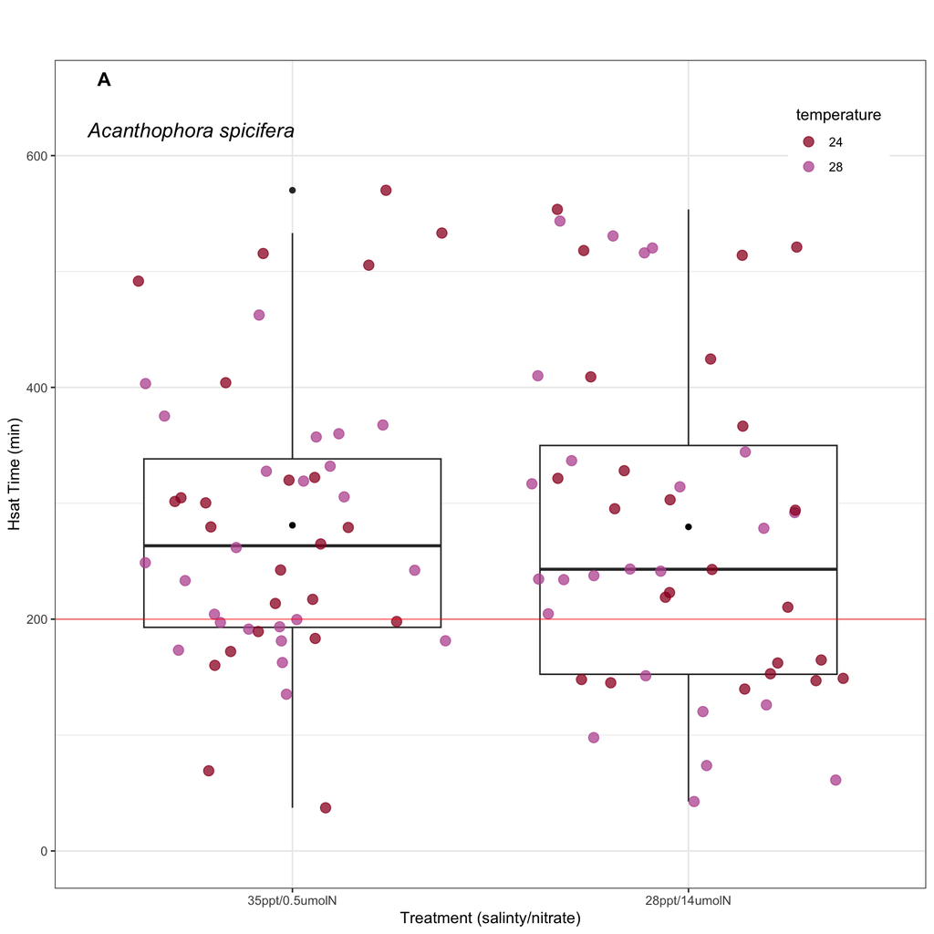

```r
ek_irrad_data %>% ggplot(aes(treatment_graph, supersat_avg)) +
        geom_boxplot(size=0.5) +
        geom_point(alpha = 0.75, size = 3, aes(color = temperature), position = "jitter", show.legend = TRUE) +
        labs(x="Treatment (salinty/nitrate)", y= "Hsat Time (min)", title= "A", subtitle = "Acanthophora spicifera") +
        scale_x_discrete(labels = c("35ppt/0.5umolN", "28ppt/14umolN")) +
        ylim(0, 650) + stat_mean() +
        geom_hline(yintercept=200, color = "red", linewidth = 0.5, alpha = 0.5) +
        scale_color_manual(values = c("#9C0627", "#BB589F")) +
        theme_bw() +
        theme(legend.position = c(0.90,0.90), plot.title = element_text(face = "bold", vjust = -15, hjust = 0.05),
              plot.subtitle = element_text(face = "italic", size = 14, vjust = -20, hjust = 0.05))
```

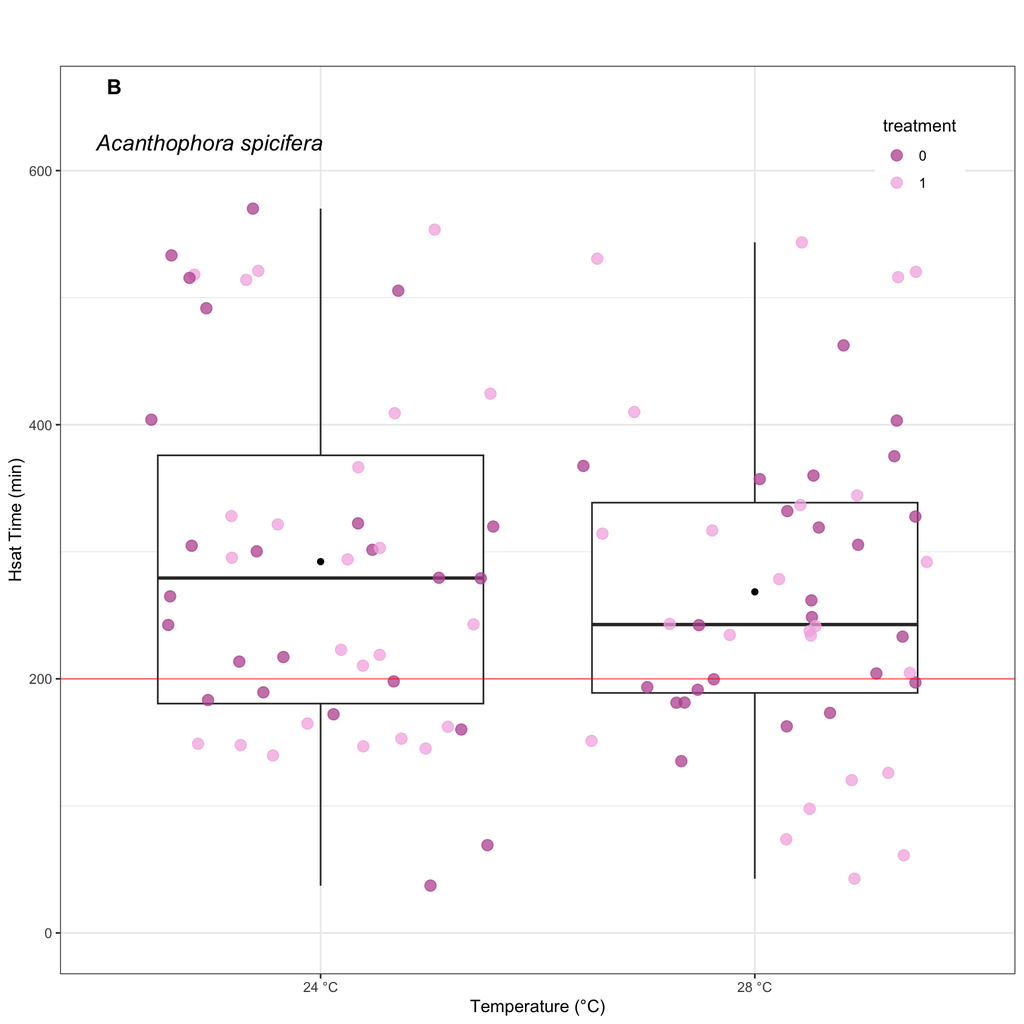

```r
ek_irrad_data %>% ggplot(aes(temperature_graph, supersat_avg)) +
  geom_boxplot(size=0.5) +
  geom_point(alpha = 0.75, size = 3, aes(color = treatment), position = "jitter", show.legend = TRUE) +
  labs(x="Temperature (°C)", y= "Hsat Time (min)", title= "B", subtitle = "Acanthophora spicifera") +
  scale_x_discrete(labels = c("24 °C", "28 °C")) +
  ylim(0, 650) + stat_mean() +
  geom_hline(yintercept=200, color = "red", linewidth = 0.5, alpha = 0.5) +
  scale_color_manual(values = c("#BB589F", "#F4B4E2")) +
  theme_bw() +
  theme(legend.position = c(0.90,0.90), plot.title = element_text(face = "bold", vjust = -15, hjust = 0.05),
        plot.subtitle = element_text(face = "italic", size = 14, vjust = -20, hjust = 0.05))
```

Summarize the means for variables of interest

```r
ek_irrad_data %>% group_by(treatment) %>% summarise_at(vars(supersat_avg), list(mean = mean))
```

```
## # A tibble: 2 × 2
##   treatment  mean
##   <fct>     <dbl>
## 1 0          281.
## 2 1          280.
```

```r
ek_irrad_data %>% group_by(temperature) %>% summarise_at(vars(supersat_avg), list(mean = mean))
```

```
## # A tibble: 2 × 2
##   temperature  mean
##   <fct>       <dbl>
## 1 24           292.
## 2 28           268.
```

```r
ek_irrad_data %>% group_by(run) %>% summarise_at(vars(day_length_avg), list(mean = mean))
```

```
## # A tibble: 2 × 2
##   run    mean
##   <fct> <dbl>
## 1 1      611.
## 2 2      598.
```

Add growth rate from other dataset to this one and subset by species for regression

```r
growth_rate <- read.csv("../input/acanthophora_growth_r1.csv")
growth_rate$treatment <- as.factor(growth_rate$treatment)
growth_rate$growth_rate_percent <- (growth_rate$final_weight - growth_rate$initial_weight) / growth_rate$initial_weight * 100
ek_irrad_data$growth_rate_percent <- growth_rate$growth_rate_percent
ek_irrad_data$apices <- growth_rate$mean_apices_per_axis
```

Plot a regression between the photosynthetic independent variables of interest and growth rate

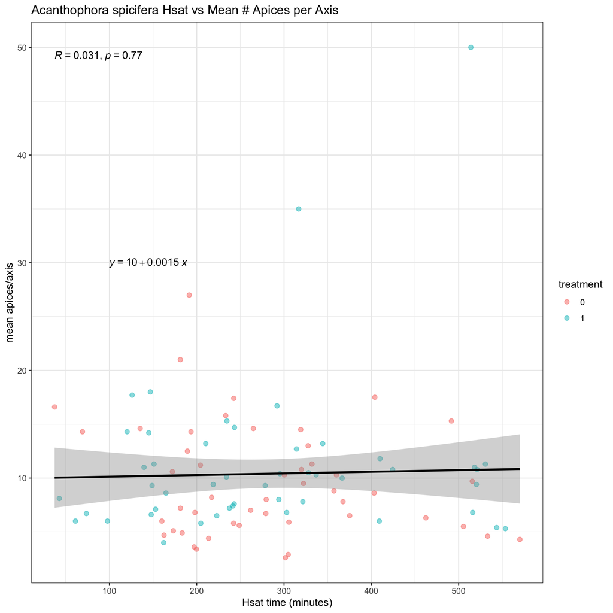

```r
acan_apices_hsat_graph <- ggplot(ek_irrad_data, aes(x=supersat_avg, y=apices)) +
        geom_point(alpha = 0.5, size = 2, show.legend = TRUE, aes(color = treatment)) +
        geom_smooth(method = "lm", col = "black") + theme_bw() +
        labs(title = "Acanthophora spicifera Hsat vs Mean # Apices per Axis", x = "Hsat time (minutes)",
             y = "mean apices/axis") + stat_regline_equation(label.x = 100, label.y = 30) + stat_cor()
acan_apices_hsat_graph
```

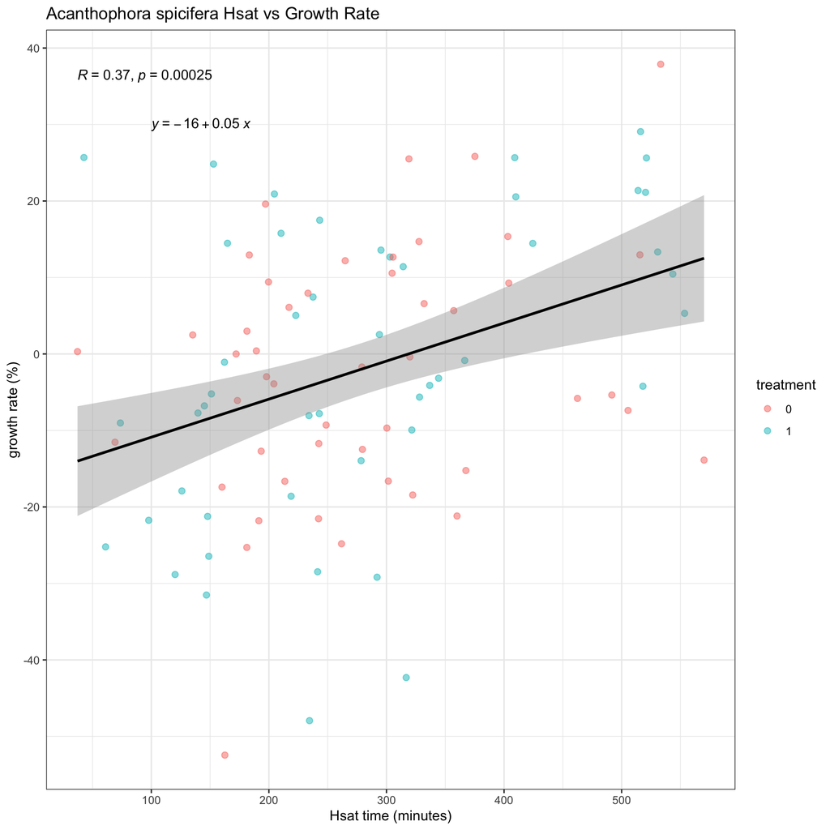

```r
acan_growth_hsat_graph <- ggplot(ek_irrad_data, aes(x=supersat_avg, y=growth_rate_percent)) +
        geom_point(alpha = 0.5, size = 2, show.legend = TRUE, aes(color = treatment)) +
        geom_smooth(method = "lm", col = "black") + theme_bw() +
        labs(title = "Acanthophora spicifera Hsat vs Growth Rate", x = "Hsat time (minutes)",
             y = "growth rate (%)") + stat_regline_equation(label.x = 100, label.y = 30) + stat_cor()
acan_growth_hsat_graph
```